# Exploratory Data Analysis - Top Hits Spotify Dataset

Agel Herdin Jonathan Sinaga

07 November, 2022

# 1 Latar Belakang

Kumpulan data yang berisi statistik audio dari 2000 lagu teratas di Spotify. Data berisi sekitar 18 kolom yang masing-masing menggambarkan trek dan kualitasnya.

# 2 Set Up

```r
library(ggplot2)
```

# 3 Data Wrangling

## 3.1 Masukkan Data

Pertama kita masukkan data **songs_normalize.csv** terlebih dahulu.

```r
top_hits <- read.csv("data_input/songs_normalize.csv")
```

Setelah itu kita melakukan inspeksi data untuk mengetahui jumlah baris, kolom dan nama kolom.

```r
head(top_hits)
```

|  | artist | song | duration_ms | explicit | year | popularity | danceability | energy | key | loudness | mode | speechiness | acousticness | instrumentalness | liveness | valence | tempo | genre |
| --- | --- | --- | --- | --- | --- | --- | --- | --- | --- | --- | --- | --- | --- | --- | --- | --- | --- | --- |
| 1 | Britney Spears | Oops!...I Did It Again | 211160 | False | 2000 | 77 | 0.751 | 0.834 | 1 | -5.444 | 0 | 0.0437 | 0.3000 | 1.77e-05 | 0.3550 | 0.894 | 95.053 | pop |
| 2 | blink-182 | All The Small Things | 167066 | False | 1999 | 79 | 0.434 | 0.897 | 0 | -4.918 | 1 | 0.0488 | 0.0103 | 0.00e+00 | 0.6120 | 0.684 | 148.726 | rock, pop |
| 3 | Faith Hill | Breathe | 250546 | False | 1999 | 66 | 0.529 | 0.496 | 7 | -9.007 | 1 | 0.0290 | 0.1730 | 0.00e+00 | 0.2510 | 0.278 | 136.859 | pop, country |
| 4 | Bon Jovi | It's My Life | 224493 | False | 2000 | 78 | 0.551 | 0.913 | 0 | -4.063 | 0 | 0.0466 | 0.0263 | 1.35e-05 | 0.3470 | 0.544 | 119.992 | rock, metal |
| 5 | *NSYNC | Bye Bye Bye | 200560 | False | 2000 | 65 | 0.614 | 0.928 | 8 | -4.806 | 0 | 0.0516 | 0.0408 | 1.04e-03 | 0.0845 | 0.879 | 172.656 | pop |
| 6 | Sisqo | Thong Song | 253733 | True | 1999 | 69 | 0.706 | 0.888 | 2 | -6.959 | 1 | 0.0654 | 0.1190 | 9.64e-05 | 0.0700 | 0.714 | 121.549 | hip hop, pop, R&B |

```r
tail(top_hits)
```

|  | artist | song | duration_ms | explicit | year | popularity | danceability | energy | key | loudness | mode | speechiness | acousticness | instrumentalness | liveness | valence | tempo | genre |
| --- | --- | --- | --- | --- | --- | --- | --- | --- | --- | --- | --- | --- | --- | --- | --- | --- | --- | --- |
| 1995 | Post Malone | Goodbyes (Feat. Young Thug) | 174960 | True | 2019 | 1 | 0.580 | 0.653 | 5 | -3.818 | 1 | 0.0745 | 0.4470 | 0.00e+00 | 0.1110 | 0.175 | 150.231 | hip hop |
| 1996 | Jonas Brothers | Sucker | 181026 | False | 2019 | 79 | 0.842 | 0.734 | 1 | -5.065 | 0 | 0.0588 | 0.0427 | 0.00e+00 | 0.1060 | 0.952 | 137.958 | pop |
| 1997 | Taylor Swift | Cruel Summer | 178426 | False | 2019 | 78 | 0.552 | 0.702 | 9 | -5.707 | 1 | 0.1570 | 0.1170 | 2.06e-05 | 0.1050 | 0.564 | 169.994 | pop |
| 1998 | Blanco Brown | The Git Up | 200593 | False | 2019 | 69 | 0.847 | 0.678 | 9 | -8.635 | 1 | 0.1090 | 0.0669 | 0.00e+00 | 0.2740 | 0.811 | 97.984 | hip hop, country |
| 1999 | Sam Smith | Dancing With A Stranger (with Normani) | 171029 | False | 2019 | 75 | 0.741 | 0.520 | 8 | -7.513 | 1 | 0.0656 | 0.4500 | 1.97e-06 | 0.2220 | 0.347 | 102.998 | pop |
| 2000 | Post Malone | Circles | 215280 | False | 2019 | 85 | 0.695 | 0.762 | 0 | -3.497 | 1 | 0.0395 | 0.1920 | 2.44e-03 | 0.0863 | 0.553 | 120.042 | hip hop |

```r
dim(top_hits)
```

```
## [1] 2000   18
```

```r
names(top_hits)
```

```
##  [1] "artist"           "song"             "duration_ms"      "explicit"
##  [5] "year"             "popularity"       "danceability"     "energy"
##  [9] "key"              "loudness"         "mode"             "speechiness"
## [13] "acousticness"     "instrumentalness" "liveness"         "valence"
## [17] "tempo"            "genre"
```

## 3.2 Modifikasi Tipe Data

Kita melakukan `str()` untuk melihat tipe data. Untuk memudahkan exploratory kita mengubah tipe data yang masih belum sesuai. Pada kolom `artist`, `year`, `key`, `mode`, `genre` kita ubah menjadi tipe data factor. Sedangkan untuk kolom `explicit` kita ubah menjadi tipe data logical.

```r
str(top_hits)
```

```
## 'data.frame':    2000 obs. of  18 variables:
##  $ artist          : chr  "Britney Spears" "blink-182" "Faith Hill" "Bon Jovi" ...
##  $ song            : chr  "Oops!...I Did It Again" "All The Small Things" "Breathe" "It's My Life" ...
##  $ duration_ms     : int  211160 167066 250546 224493 200560 253733 284200 258560 271333 307153 ...
##  $ explicit        : chr  "False" "False" "False" "False" ...
##  $ year            : int  2000 1999 1999 2000 2000 1999 2000 2000 1999 2001 ...
##  $ popularity      : int  77 79 66 78 65 69 86 68 75 77 ...
##  $ danceability    : num  0.751 0.434 0.529 0.551 0.614 0.706 0.949 0.708 0.713 0.72 ...
##  $ energy          : num  0.834 0.897 0.496 0.913 0.928 0.888 0.661 0.772 0.678 0.808 ...
##  $ key             : int  1 0 7 0 8 2 5 7 5 6 ...
##  $ loudness        : num  -5.44 -4.92 -9.01 -4.06 -4.81 ...
##  $ mode            : int  0 1 1 0 0 1 0 1 0 1 ...
##  $ speechiness     : num  0.0437 0.0488 0.029 0.0466 0.0516 0.0654 0.0572 0.0322 0.102 0.0379 ...
##  $ acousticness    : num  0.3 0.0103 0.173 0.0263 0.0408 0.119 0.0302 0.0267 0.273 0.00793 ...
##  $ instrumentalness: num  1.77e-05 0.00 0.00 1.35e-05 1.04e-03 9.64e-05 0.00 0.00 0.00 2.93e-02 ...
##  $ liveness        : num  0.355 0.612 0.251 0.347 0.0845 0.07 0.0454 0.467 0.149 0.0634 ...
##  $ valence         : num  0.894 0.684 0.278 0.544 0.879 0.714 0.76 0.861 0.734 0.869 ...
##  $ tempo           : num  95.1 148.7 136.9 120 172.7 ...
##  $ genre           : chr  "pop" "rock, pop" "pop, country" "rock, metal" ...
```

```r
top_hits$artist <- as.factor(top_hits$artist)
top_hits$explicit <- as.logical(top_hits$explicit)
top_hits$year <- as.factor(top_hits$year)
top_hits$key <- as.factor(top_hits$key)
top_hits$mode <- as.factor(top_hits$mode)
top_hits$genre <- as.factor(top_hits$genre)

str(top_hits)
```

```
## 'data.frame':    2000 obs. of  18 variables:
##  $ artist          : Factor w/ 835 levels "*NSYNC","112",..: 123 105 258 115 1 696 243 643 202 538 ...
##  $ song            : chr  "Oops!...I Did It Again" "All The Small Things" "Breathe" "It's My Life" ...
##  $ duration_ms     : int  211160 167066 250546 224493 200560 253733 284200 258560 271333 307153 ...
##  $ explicit        : logi  FALSE FALSE FALSE FALSE FALSE TRUE ...
##  $ year            : Factor w/ 23 levels "1998","1999",..: 3 2 2 3 3 2 3 3 2 4 ...
##  $ popularity      : int  77 79 66 78 65 69 86 68 75 77 ...
##  $ danceability    : num  0.751 0.434 0.529 0.551 0.614 0.706 0.949 0.708 0.713 0.72 ...
##  $ energy          : num  0.834 0.897 0.496 0.913 0.928 0.888 0.661 0.772 0.678 0.808 ...
##  $ key             : Factor w/ 12 levels "0","1","2","3",..: 2 1 8 1 9 3 6 8 6 7 ...
##  $ loudness        : num  -5.44 -4.92 -9.01 -4.06 -4.81 ...
##  $ mode            : Factor w/ 2 levels "0","1": 1 2 2 1 1 2 1 2 1 2 ...
##  $ speechiness     : num  0.0437 0.0488 0.029 0.0466 0.0516 0.0654 0.0572 0.0322 0.102 0.0379 ...
##  $ acousticness    : num  0.3 0.0103 0.173 0.0263 0.0408 0.119 0.0302 0.0267 0.273 0.00793 ...
##  $ instrumentalness: num  1.77e-05 0.00 0.00 1.35e-05 1.04e-03 9.64e-05 0.00 0.00 0.00 2.93e-02 ...
##  $ liveness        : num  0.355 0.612 0.251 0.347 0.0845 0.07 0.0454 0.467 0.149 0.0634 ...
##  $ valence         : num  0.894 0.684 0.278 0.544 0.879 0.714 0.76 0.861 0.734 0.869 ...
##  $ tempo           : num  95.1 148.7 136.9 120 172.7 ...
##  $ genre           : Factor w/ 59 levels "country","country, latin",..: 24 48 25 47 24 16 8 34 31 3 ...
```

## 3.3 Cek Missing Value

Untuk melihat apakah ada missing value di tiap kolom kita dapat menggunakan `is.na()` atau `anyNA()`.

```r
colSums(is.na(top_hits))
```

```
##           artist             song      duration_ms         explicit
##                0                0                0                0
##             year       popularity     danceability           energy
##                0                0                0                0
##              key         loudness             mode      speechiness
##                0                0                0                0
##     acousticness instrumentalness         liveness          valence
##                0                0                0                0
##            tempo            genre
##                0                0
```

```r
anyNA(top_hits)
```

```
## [1] FALSE
```

## 3.4 Hapus Duplicate Rows

Dalam kasus ini kita perlu menghapus baris yang bersifat duplikat. Kolom `song` dijadikan acuan dan mengambil baris yang pertama. Sebelum itu kita mengurutkannya terlebih dahulu berdasarkan `popularity`.

```r
top_hits2 <- top_hits[order(top_hits$popularity, decreasing = TRUE),]
top_hits3 <- top_hits2[match(unique(top_hits2$song), top_hits2$song), ]
nrow(top_hits3)
```

```
## [1] 1879
```

## 3.5 Menambah dan Mengubah Kolom

Kita perlu menambah beberapa kolom baru untuk exploratory yang lebih mendalam. Kolom pertama adalah `popularity_range` yang berisi kategori range dari popularity lagu tersebut. Hal ini bertujuan untuk memudahkan exploratory dengan metode sampling pada data paling atas, data paling bawah, dan data yang berada di tengah.

```r
convert_popularity <- function(y){
    if(y >= 91 & y <= 100)
      {
      y <- "91-100"
    }
    else
      if(y >= 81 & y <= 90)
      {
      y <- "81-90"
    }
    else
      if(y >= 71 & y <= 80)
      {
      y <- "71-80"
    }
    else
      if(y >= 61 & y <= 70)
      {
      y <- "61-70"
    }
    else
      if(y >= 51 & y <= 60)
      {
      y <- "51-60"
    }
    else
      if(y >= 41 & y <= 50)
      {
      y <- "41-50"
    }
    else
      if(y >= 31 & y <= 40)
      {
      y <- "31-40"
    }
    else
      if(y >= 21 & y <= 30)
      {
      y <- "21-30"
    }
    else
      if(y >= 11 & y <= 20)
      {
      y <- "11-20"
    }
    else
      {
      y <- "0-10"
    }
}

top_hits3$popularity_range <- sapply(X = top_hits3$popularity,
                                    FUN = convert_popularity)
```

Selain itu membuat kolom `key_name`, `tempo_category`, dan `year_range` untuk mempermudah kita dalam menggali insight.

```r
convert_key <- function(y){
    if(y %in% 0)
      {
      y <- "C"
    }
    else
      if(y %in% 1)
      {
      y <- "C#/Db"
    }
    else
      if(y %in% 2)
      {
      y <- "D"
    }
    else
      if(y %in% 3)
      {
      y <- "D#/Eb"
    }
    else
      if(y %in% 4)
      {
      y <- "E"
    }
    else
      if(y %in% 5)
      {
      y <- "F"
    }
    else
      if(y %in% 6)
      {
      y <- "F#/Gb"
    }
    else
      if(y %in% 7)
      {
      y <- "G"
    }
    else
      if(y %in% 8)
      {
      y <- "G#/Ab"
    }
    else
      if(y %in% 9)
      {
      y <- "A"
    }
    else
      if(y %in% 10)
      {
      y <- "A#/Bb"
    }
    else
      if(y %in% 11)
      {
      y <- "B"
      }
    else
      if(y %in% 12)
      {
      y <- "C'"
    }
    else
      {
      y <- "NA"
    }
}

top_hits3$key_name <- sapply(X = top_hits3$key,
                             FUN = convert_key)
```

```r
convert_tempo <- function(y){
    if(y >= 20 & y <= 77)
      {
      y <- "Lambat"
    }
    else
      if(y >= 86 & y <= 109)
      {
      y <- "Sedang"
    }
    else
      {
      y <- "Cepat"
    }
}

top_hits3$tempo_category <- sapply(X = top_hits3$tempo,
                                 FUN = convert_tempo)
```

```r
convert_year <- function(y){
    if(y %in% 1998:2002)
      {
      y <- "1998-2002"
    }
    else
      if(y %in% 2003:2007)
      {
      y <- "2003-2007"
    }
    else
      if(y %in% 2008:2012)
      {
      y <- "2008-2012"
    }
    else
      if(y %in% 2013:2017)
      {
      y <- "2013-2017"
    }
    else
      {
      y <- "2018-2020"
    }
}

top_hits3$year_range <- sapply(X = top_hits3$year,
                              FUN = convert_year)
```

Yang terakhir kita perlu mengubah satuan durasi lagu yang sebelumnya dalam milidetik menjadi detik.

```r
top_hits3$duration_ms <- top_hits3$duration_ms / 1000
top_hits4 <- dplyr::rename(top_hits3, duration_s = duration_ms)
```

## 3.6 Data Explanation

```r
top_hits4
```

|  | artist | song | duration_s | explicit | year | popularity | danceability | energy | key | loudness | mode | speechiness | acousticness | instrumentalness | liveness | valence | tempo | genre | popularity_range | key_name | tempo_category | year_range |
| --- | --- | --- | --- | --- | --- | --- | --- | --- | --- | --- | --- | --- | --- | --- | --- | --- | --- | --- | --- | --- | --- | --- |
| 1323 | The Neighbourhood | Sweater Weather | 240.400 | FALSE | 2013 | 89 | 0.612 | 0.8070 | 10 | -2.810 | 1 | 0.0336 | 4.95e-02 | 1.77e-02 | 0.1010 | 0.3980 | 124.053 | rock, pop | 81-90 | A#/Bb | Cepat | 2013-2017 |
| 1312 | Tom Odell | Another Love | 244.360 | TRUE | 2013 | 88 | 0.445 | 0.5370 | 4 | -8.532 | 0 | 0.0400 | 6.95e-01 | 1.65e-05 | 0.0944 | 0.1310 | 122.769 | pop | 81-90 | E | Cepat | 2013-2017 |
| 202 | Eminem | Without Me | 290.320 | TRUE | 2002 | 87 | 0.908 | 0.6690 | 7 | -2.827 | 1 | 0.0738 | 2.86e-03 | 0.00e+00 | 0.2370 | 0.6620 | 112.238 | hip hop | 81-90 | G | Cepat | 1998-2002 |
| 7 | Eminem | The Real Slim Shady | 284.200 | TRUE | 2000 | 86 | 0.949 | 0.6610 | 5 | -4.244 | 0 | 0.0572 | 3.02e-02 | 0.00e+00 | 0.0454 | 0.7600 | 104.504 | hip hop | 81-90 | F | Sedang | 1998-2002 |
| 1614 | WILLOW | Wait a Minute! | 196.520 | FALSE | 2015 | 86 | 0.764 | 0.7050 | 3 | -5.279 | 0 | 0.0278 | 3.71e-02 | 1.94e-05 | 0.0943 | 0.6720 | 101.003 | pop, R&B, Dance/Electronic | 81-90 | D#/Eb | Sedang | 2013-2017 |
| 1820 | Billie Eilish | lovely (with Khalid) | 200.185 | FALSE | 2018 | 86 | 0.351 | 0.2960 | 4 | -10.109 | 0 | 0.0333 | 9.34e-01 | 0.00e+00 | 0.0950 | 0.1200 | 115.284 | pop, Dance/Electronic | 81-90 | E | Cepat | 2018-2020 |
| 210 | Eminem | 'Till I Collapse | 297.786 | TRUE | 2002 | 85 | 0.548 | 0.8470 | 1 | -3.237 | 1 | 0.1860 | 6.22e-02 | 0.00e+00 | 0.0816 | 0.1000 | 171.447 | hip hop | 81-90 | C#/Db | Cepat | 1998-2002 |
| 1228 | Bruno Mars | Locked out of Heaven | 233.478 | FALSE | 2012 | 85 | 0.726 | 0.6980 | 5 | -4.165 | 1 | 0.0431 | 4.90e-02 | 0.00e+00 | 0.3090 | 0.8670 | 143.994 | pop | 81-90 | F | Cepat | 2008-2012 |
| 1513 | The Neighbourhood | Daddy Issues | 260.173 | FALSE | 2015 | 85 | 0.588 | 0.5210 | 10 | -9.461 | 1 | 0.0329 | 6.78e-02 | 1.49e-01 | 0.1230 | 0.3370 | 85.012 | rock, pop | 81-90 | A#/Bb | Cepat | 2013-2017 |
| 1515 | Avicii | The Nights | 176.658 | FALSE | 2014 | 85 | 0.527 | 0.8350 | 6 | -5.298 | 1 | 0.0433 | 1.66e-02 | 0.00e+00 | 0.2490 | 0.6540 | 125.983 | pop, Dance/Electronic | 81-90 | F#/Gb | Cepat | 2013-2017 |

[output cut: 1869 more lines]

**Penjelasan yang didapat dari proses wrangling data di atas adalah:**  
1. Dataset **top_hits** memiliki 2000 baris dan 18 kolom.  
2. Tipe data pada kolom `artist`, `year`, `key`, `mode`, `genre` diubah menjadi factor dan kolom `explicit` menjadi logical.  
3. Dataset tidak memiliki missing value.  
4. Jumlah baris setelah data duplikat dihapus menjadi 1879.  
5. Kolom `popularity_range` ditambah untuk mempermudah pengambilan sampling pada data atas, data bawah, dan data di tengah. Kolom `key_name`, `tempo_category`, dan `year_range`, dan `duration_s` dibuat untuk mempermudah kita dalam menggali insight.

# 4 Data Exploratory

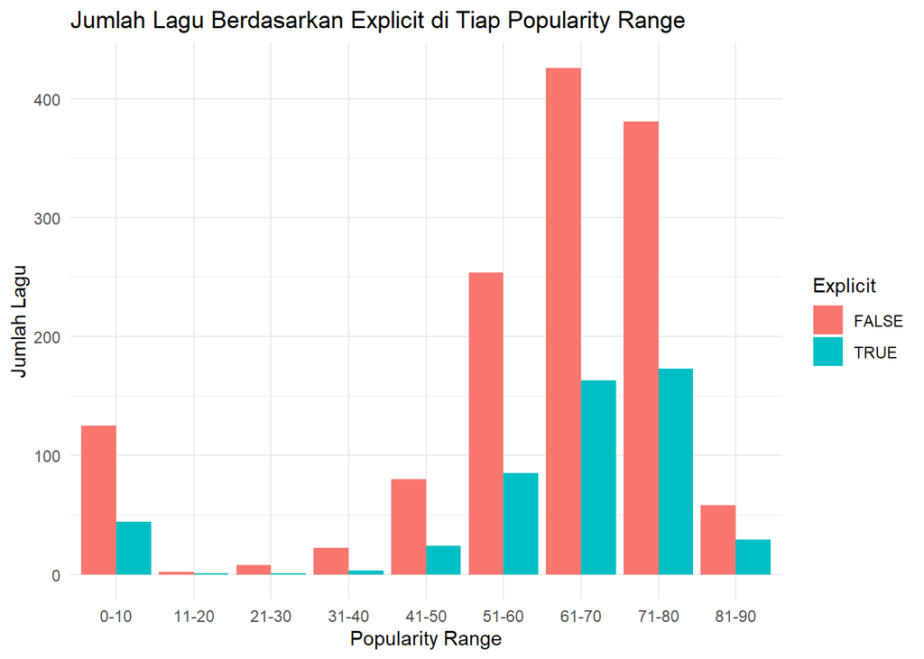

```r
explicit <- data.frame(table(top_hits4[c('explicit', 'popularity_range')]))

ggplot(data=explicit, aes(x=popularity_range, y=Freq, fill=explicit)) +
      geom_bar(stat="identity", position=position_dodge())+
      ggtitle('Jumlah Lagu Berdasarkan Explicit di Tiap Popularity Range')+
      xlab('Popularity Range')+ylab('Jumlah Lagu')+
      labs(fill='Explicit')+
      theme_minimal()
```

```r
key_name <- data.frame(table(top_hits4[c('key_name', 'popularity_range')]))
key_name_major <- subset(key_name, key_name %in% c('C', 'D', 'E', 'F', 'G', 'A', 'B'))
key_name_minor <- subset(key_name, key_name %in% c('C#/Db', 'D#/Eb', 'F#/Gb', 'G#/Ab', 'A#/Bb'))
```

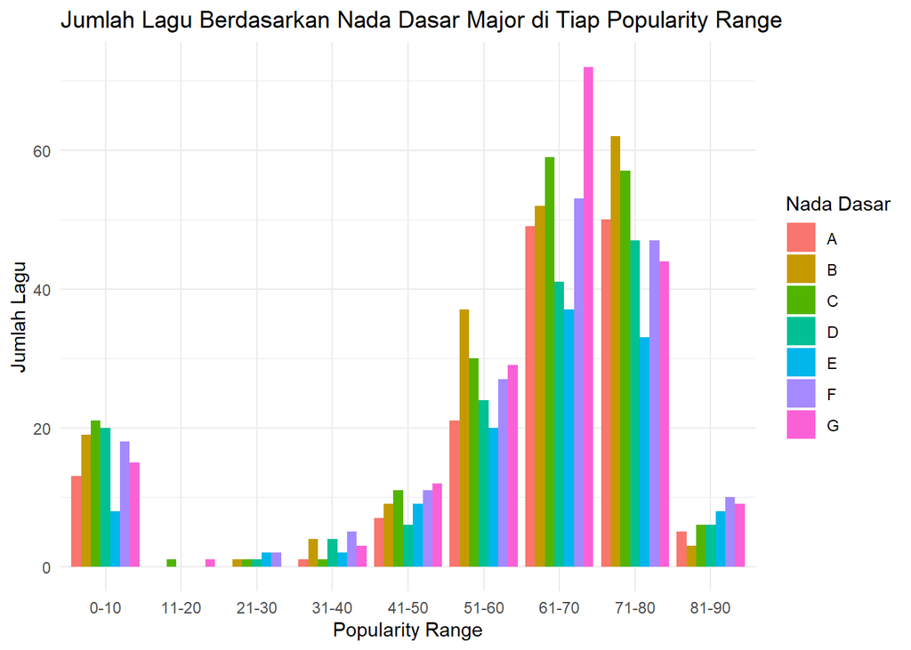

```r
ggplot(data=key_name_major, aes(x=popularity_range, y=Freq, fill=key_name)) +
      geom_bar(stat="identity", position=position_dodge())+
      ggtitle('Jumlah Lagu Berdasarkan Nada Dasar Major di Tiap Popularity Range')+
      xlab('Popularity Range')+ylab('Jumlah Lagu')+
      labs(fill='Nada Dasar')+
      theme_minimal()
```

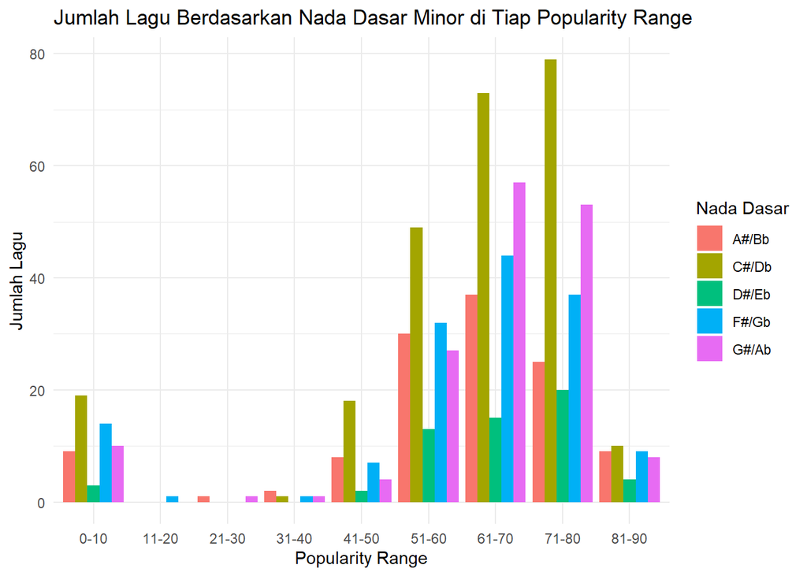

```r
ggplot(data=key_name_minor, aes(x=popularity_range, y=Freq, fill=key_name)) +
      geom_bar(stat="identity", position=position_dodge())+
      ggtitle('Jumlah Lagu Berdasarkan Nada Dasar Minor di Tiap Popularity Range')+
      xlab('Popularity Range')+ylab('Jumlah Lagu')+
      labs(fill='Nada Dasar')+
      theme_minimal()
```

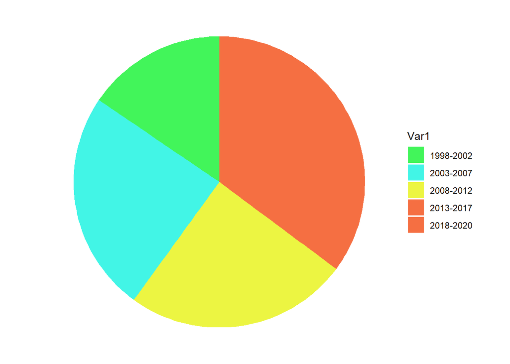

```r
pie_chart1 <- data.frame(prop.table(table(top_hits4$year_range))*100)

mycols <- c("#42f55a", "#42f5e6", "#ecf542", "#f56f42", "#f56f42")

ggplot(pie_chart1, aes(x = "", y = Freq, fill = Var1)) +
    geom_bar(width = 1, stat = "identity") +
    coord_polar("y", start = 0)+
    scale_fill_manual(values = mycols) +
    theme_void()
```

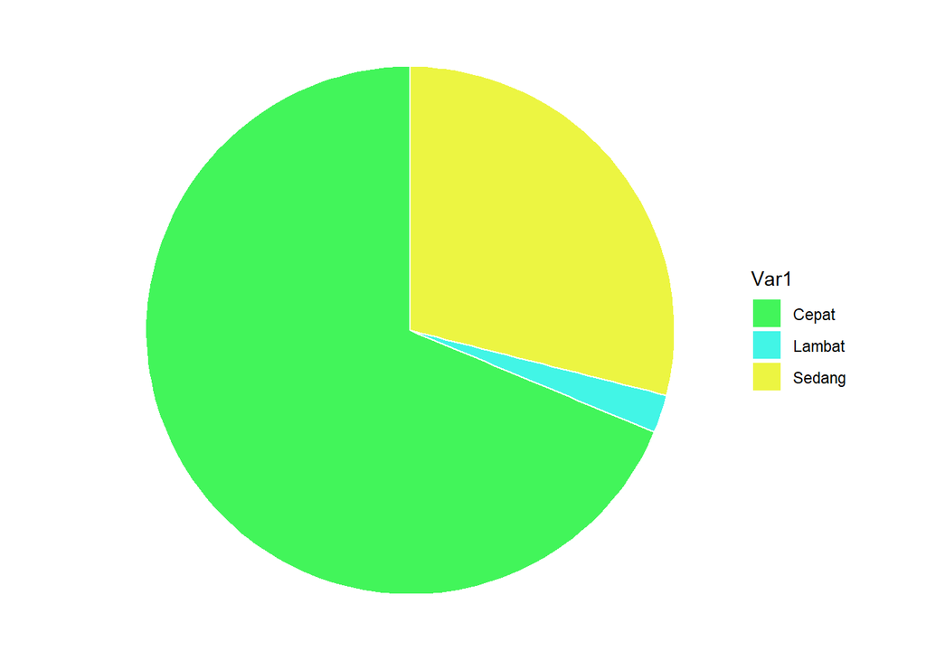

```r
pie_chart2 <- data.frame(prop.table(table(top_hits4$tempo_category))*100)

mycols <- c("#42f55a", "#42f5e6", "#ecf542")

ggplot(pie_chart2, aes(x = "", y = Freq, fill = Var1)) +
    geom_bar(width = 1, stat = "identity", color = "white") +
    coord_polar("y", start = 0)+
    scale_fill_manual(values = mycols) +
    theme_void()
```

## 4.1 Max

```r
tophits_max <- subset(top_hits4, popularity_range %in% '81-90')
summary(tophits_max)
```

```
##            artist       song             duration_s     explicit
##  Eminem       : 5   Length:87          Min.   :119.1   Mode :logical
##  Billie Eilish: 3   Class :character   1st Qu.:198.1   FALSE:58
##  Ed Sheeran   : 3   Mode  :character   Median :221.2   TRUE :29
##  One Direction: 3                      Mean   :225.4
##  Post Malone  : 3                      3rd Qu.:249.4
##  XXXTENTACION : 3                      Max.   :404.1
##  (Other)      :67
##       year      popularity     danceability        energy            key
##  2018   :15   Min.   :81.00   Min.   :0.3510   Min.   :0.2640   1      :10
##  2015   : 8   1st Qu.:81.00   1st Qu.:0.5935   1st Qu.:0.5470   5      :10
##  2017   : 8   Median :82.00   Median :0.7050   Median :0.7050   6      : 9
##  2012   : 7   Mean   :82.67   Mean   :0.6895   Mean   :0.6714   7      : 9
##  2013   : 7   3rd Qu.:84.00   3rd Qu.:0.7805   3rd Qu.:0.8050   10     : 9
##  2019   : 7   Max.   :89.00   Max.   :0.9490   Max.   :0.9700   4      : 8
##  (Other):35                                                     (Other):32
##     loudness       mode    speechiness       acousticness
##  Min.   :-12.808   0:32   Min.   :0.02320   Min.   :0.00264
##  1st Qu.: -6.720   1:55   1st Qu.:0.03655   1st Qu.:0.03255
##  Median : -5.609          Median :0.05840   Median :0.08630
##  Mean   : -5.781          Mean   :0.10707   Mean   :0.21160
##  3rd Qu.: -4.174          3rd Qu.:0.13800   3rd Qu.:0.27100
##  Max.   : -1.538          Max.   :0.39200   Max.   :0.93400
##
##  instrumentalness       liveness          valence           tempo
##  Min.   :0.0000000   Min.   :0.03440   Min.   :0.1000   Min.   : 65.04
##  1st Qu.:0.0000000   1st Qu.:0.09435   1st Qu.:0.3635   1st Qu.: 95.17
##  Median :0.0000000   Median :0.11900   Median :0.5300   Median :112.24
##  Mean   :0.0075324   Mean   :0.17637   Mean   :0.5272   Mean   :113.90
##  3rd Qu.:0.0000758   3rd Qu.:0.23950   3rd Qu.:0.7400   3rd Qu.:128.48
##  Max.   :0.1810000   Max.   :0.63900   Max.   :0.9650   Max.   :176.17
##
##                    genre    popularity_range     key_name
##  hip hop              :18   Length:87          Length:87
##  pop                  :18   Class :character   Class :character
##  pop, Dance/Electronic: 9   Mode  :character   Mode  :character
##  hip hop, pop         : 8
##  rock                 : 5
##  rock, pop            : 5
##  (Other)              :24
##  tempo_category      year_range
##  Length:87          Length:87
##  Class :character   Class :character
##  Mode  :character   Mode  :character
##
##
##
##
```

```r
genre_max <- tophits_max[c('genre', 'tempo_category')]
genre_max2 <- data.frame(table(genre_max))
```

```r
genre_cepat_max <- subset(genre_max2, tempo_category %in% 'Cepat')
genre_cepat_max2 <- genre_cepat_max[order(genre_cepat_max$Freq, decreasing = TRUE),]
head(genre_cepat_max2)
```

|  | genre | tempo_category | Freq |
| --- | --- | --- | --- |
| 8 | hip hop | Cepat | 13 |
| 24 | pop | Cepat | 12 |
| 26 | pop, Dance/Electronic | Cepat | 5 |
| 48 | rock, pop | Cepat | 4 |
| 10 | hip hop, Dance/Electronic | Cepat | 3 |
| 15 | hip hop, pop, latin | Cepat | 3 |

```r
genre_sedang_max <- subset(genre_max2, tempo_category %in% 'Sedang')
genre_sedang_max2 <- genre_sedang_max[order(genre_sedang_max$Freq, decreasing = TRUE),]
head(genre_sedang_max2)
```

|  | genre | tempo_category | Freq |
| --- | --- | --- | --- |
| 130 | hip hop, pop | Sedang | 6 |
| 126 | hip hop | Sedang | 4 |
| 142 | pop | Sedang | 4 |
| 144 | pop, Dance/Electronic | Sedang | 4 |
| 157 | rock | Sedang | 3 |
| 134 | hip hop, pop, R&B | Sedang | 2 |

```r
genre_lambat_max <- subset(genre_max2, tempo_category %in% 'Lambat')
genre_lambat_max2 <- genre_lambat_max[order(genre_lambat_max$Freq, decreasing = TRUE),]
head(genre_lambat_max2)
```

|  | genre | tempo_category | Freq |
| --- | --- | --- | --- |
| 83 | pop | Lambat | 2 |
| 67 | hip hop | Lambat | 1 |
| 60 | country | Lambat | 0 |
| 61 | country, latin | Lambat | 0 |
| 62 | Dance/Electronic | Lambat | 0 |
| 63 | easy listening | Lambat | 0 |

```r
genre_max3 <- tophits_max[c('genre', 'year_range')]
genre_max4 <- data.frame(table(genre_max3))
```

```r
year_range_max <- subset(genre_max4, year_range %in% '2018-2020')
year_range_max2 <- year_range_max[order(year_range_max$Freq, decreasing = TRUE),]
head(year_range_max2)
```

|  | genre | year_range | Freq |
| --- | --- | --- | --- |
| 244 | hip hop | 2018-2020 | 5 |
| 262 | pop, Dance/Electronic | 2018-2020 | 5 |
| 260 | pop | 2018-2020 | 3 |
| 239 | Dance/Electronic | 2018-2020 | 1 |
| 246 | hip hop, Dance/Electronic | 2018-2020 | 1 |
| 248 | hip hop, pop | 2018-2020 | 1 |

```r
year_range_max3 <- subset(genre_max4, year_range %in% '2013-2017')
year_range_max4 <- year_range_max3[order(year_range_max3$Freq, decreasing = TRUE),]
head(year_range_max4)
```

|  | genre | year_range | Freq |
| --- | --- | --- | --- |
| 201 | pop | 2013-2017 | 9 |
| 203 | pop, Dance/Electronic | 2013-2017 | 4 |
| 185 | hip hop | 2013-2017 | 3 |
| 216 | rock | 2013-2017 | 3 |
| 225 | rock, pop | 2013-2017 | 3 |
| 187 | hip hop, Dance/Electronic | 2013-2017 | 2 |

```r
year_range_max5 <- subset(genre_max4, year_range %in% '2008-2012')
year_range_max6 <- year_range_max5[order(year_range_max5$Freq, decreasing = TRUE),]
head(year_range_max6)
```

|  | genre | year_range | Freq |
| --- | --- | --- | --- |
| 142 | pop | 2008-2012 | 5 |
| 126 | hip hop | 2008-2012 | 4 |
| 130 | hip hop, pop | 2008-2012 | 3 |
| 166 | rock, pop | 2008-2012 | 2 |
| 133 | hip hop, pop, latin | 2008-2012 | 1 |
| 134 | hip hop, pop, R&B | 2008-2012 | 1 |

```r
year_range_max7 <- subset(genre_max4, year_range %in% '2003-2007')
year_range_max8 <- year_range_max7[order(year_range_max7$Freq, decreasing = TRUE),]
head(year_range_max8)
```

|  | genre | year_range | Freq |
| --- | --- | --- | --- |
| 74 | hip hop, pop, latin | 2003-2007 | 2 |
| 67 | hip hop | 2003-2007 | 1 |
| 71 | hip hop, pop | 2003-2007 | 1 |
| 75 | hip hop, pop, R&B | 2003-2007 | 1 |
| 83 | pop | 2003-2007 | 1 |
| 89 | pop, latin | 2003-2007 | 1 |

```r
year_range_max9 <- subset(genre_max4, year_range %in% '1998-2002')
year_range_max10 <- year_range_max9[order(year_range_max9$Freq, decreasing = TRUE),]
head(year_range_max10)
```

|  | genre | year_range | Freq |
| --- | --- | --- | --- |
| 8 | hip hop | 1998-2002 | 5 |
| 12 | hip hop, pop | 1998-2002 | 1 |
| 47 | rock, metal | 1998-2002 | 1 |
| 1 | country | 1998-2002 | 0 |
| 2 | country, latin | 1998-2002 | 0 |
| 3 | Dance/Electronic | 1998-2002 | 0 |

```r
duration_s_max <- aggregate(duration_s ~ year_range, tophits_max, mean)
head(duration_s_max)
```

|  | year_range | duration_s |
| --- | --- | --- |
| 1 | 1998-2002 | 275.0434 |
| 2 | 2003-2007 | 216.7914 |
| 3 | 2008-2012 | 231.3044 |
| 4 | 2013-2017 | 225.8506 |
| 5 | 2018-2020 | 207.6811 |

```r
danceability_max <- aggregate(danceability ~ year_range, tophits_max, mean)
head(danceability_max)
```

|  | year_range | danceability |
| --- | --- | --- |
| 1 | 1998-2002 | 0.7865714 |
| 2 | 2003-2007 | 0.7923750 |
| 3 | 2008-2012 | 0.6648235 |
| 4 | 2013-2017 | 0.6622424 |
| 5 | 2018-2020 | 0.6811818 |

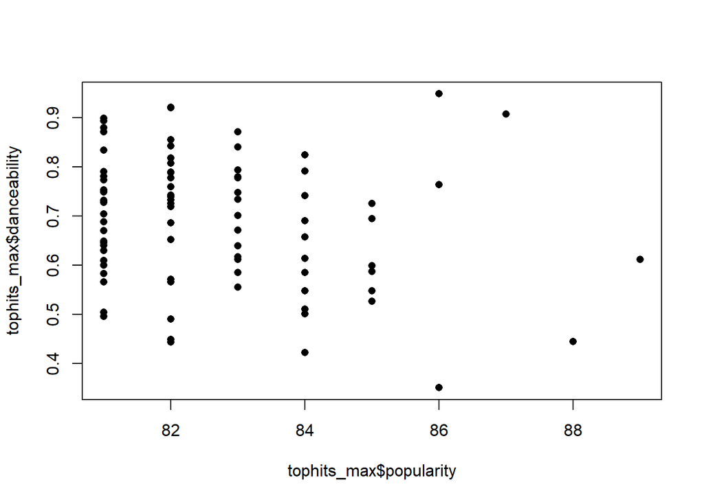

```r
plot(x = tophits_max$popularity,
     y = tophits_max$danceability,
     pch = 16)
```

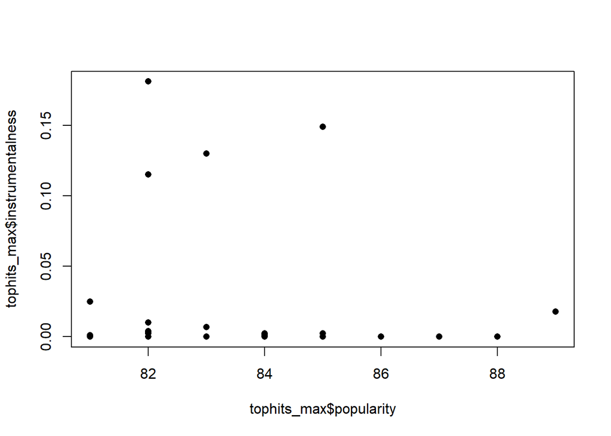

```r
plot(x = tophits_max$popularity,
     y = tophits_max$instrumentalness,
     pch = 16)
```

## 4.2 Median

```r
tophits_median <- subset(top_hits4, popularity_range %in% c('51-60', '41-50'))
summary(tophits_median)
```

```
##             artist        song             duration_s     explicit
##  Ludacris      :  6   Length:443         Min.   :144.2   Mode :logical
##  P!nk          :  5   Class :character   1st Qu.:210.0   FALSE:334
##  Blue          :  4   Mode  :character   Median :228.0   TRUE :109
##  Britney Spears:  4                      Mean   :235.6
##  David Guetta  :  4                      3rd Qu.:254.9
##  Girls Aloud   :  4                      Max.   :452.9
##  (Other)       :416
##       year       popularity     danceability        energy            key
##  2001   : 41   Min.   :41.00   Min.   :0.1800   Min.   :0.2190   1      : 67
##  2004   : 41   1st Qu.:51.00   1st Qu.:0.5855   1st Qu.:0.6425   11     : 46
##  2003   : 36   Median :55.00   Median :0.6810   Median :0.7510   0      : 41
##  2000   : 35   Mean   :54.03   Mean   :0.6698   Mean   :0.7398   7      : 41
##  2002   : 35   3rd Qu.:58.00   3rd Qu.:0.7690   3rd Qu.:0.8625   6      : 39
##  2006   : 29   Max.   :60.00   Max.   :0.9690   Max.   :0.9820   5      : 38
##  (Other):226                                                     (Other):171
##     loudness       mode     speechiness       acousticness
##  Min.   :-15.636   0:200   Min.   :0.02390   Min.   :0.0000382
##  1st Qu.: -6.620   1:243   1st Qu.:0.03855   1st Qu.:0.0127500
##  Median : -5.210           Median :0.06080   Median :0.0593000
##  Mean   : -5.566           Mean   :0.10502   Mean   :0.1187146
##  3rd Qu.: -4.229           3rd Qu.:0.13150   3rd Qu.:0.1725000
##  Max.   : -0.276           Max.   :0.57600   Max.   :0.8560000
##
##  instrumentalness       liveness          valence           tempo
##  Min.   :0.0000000   Min.   :0.02630   Min.   :0.0783   Min.   : 70.54
##  1st Qu.:0.0000000   1st Qu.:0.08745   1st Qu.:0.4425   1st Qu.: 96.09
##  Median :0.0000000   Median :0.13500   Median :0.5950   Median :118.01
##  Mean   :0.0189476   Mean   :0.18522   Mean   :0.5917   Mean   :117.26
##  3rd Qu.:0.0001765   3rd Qu.:0.25650   3rd Qu.:0.7685   3rd Qu.:130.35
##  Max.   :0.8940000   Max.   :0.84300   Max.   :0.9730   Max.   :205.57
##
##                    genre     popularity_range     key_name
##  pop                  : 74   Length:443         Length:443
##  hip hop, pop, R&B    : 66   Class :character   Class :character
##  hip hop, pop         : 58   Mode  :character   Mode  :character
##  pop, R&B             : 55
##  pop, Dance/Electronic: 53
##  Dance/Electronic     : 23
##  (Other)              :114
##  tempo_category      year_range
##  Length:443         Length:443
##  Class :character   Class :character
##  Mode  :character   Mode  :character
##
##
##
##
```

```r
genre_median <- tophits_median[c('genre', 'tempo_category')]
genre_median2 <- data.frame(table(genre_median))
```

```r
genre_cepat_median <- subset(genre_median2, tempo_category %in% 'Cepat')
genre_cepat_median2 <- genre_cepat_median[order(genre_cepat_median$Freq, decreasing = TRUE),]
head(genre_cepat_median2)
```

|  | genre | tempo_category | Freq |
| --- | --- | --- | --- |
| 24 | pop | Cepat | 54 |
| 26 | pop, Dance/Electronic | Cepat | 44 |
| 12 | hip hop, pop | Cepat | 33 |
| 16 | hip hop, pop, R&B | Cepat | 30 |
| 31 | pop, R&B | Cepat | 29 |
| 3 | Dance/Electronic | Cepat | 22 |

```r
genre_sedang_median <- subset(genre_median2, tempo_category %in% 'Sedang')
genre_sedang_median2 <- genre_sedang_median[order(genre_sedang_median$Freq, decreasing = TRUE),]
head(genre_sedang_median2)
```

|  | genre | tempo_category | Freq |
| --- | --- | --- | --- |
| 134 | hip hop, pop, R&B | Sedang | 35 |
| 130 | hip hop, pop | Sedang | 24 |
| 149 | pop, R&B | Sedang | 22 |
| 142 | pop | Sedang | 19 |
| 144 | pop, Dance/Electronic | Sedang | 9 |
| 126 | hip hop | Sedang | 8 |

```r
genre_lambat_median <- subset(genre_median2, tempo_category %in% 'Lambat')
genre_lambat_median2 <- genre_lambat_median[order(genre_lambat_median$Freq, decreasing = TRUE),]
head(genre_lambat_median2)
```

|  | genre | tempo_category | Freq |
| --- | --- | --- | --- |
| 90 | pop, R&B | Lambat | 4 |
| 71 | hip hop, pop | Lambat | 1 |
| 73 | hip hop, pop, Dance/Electronic | Lambat | 1 |
| 75 | hip hop, pop, R&B | Lambat | 1 |
| 83 | pop | Lambat | 1 |
| 112 | set() | Lambat | 1 |

```r
genre_median3 <- tophits_median[c('genre', 'year_range')]
genre_median4 <- data.frame(table(genre_median3))
```

```r
year_range_median <- subset(genre_median4, year_range %in% '2018-2020')
year_range_median2 <- year_range_median[order(year_range_median$Freq, decreasing = TRUE),]
head(year_range_median2)
```

|  | genre | year_range | Freq |
| --- | --- | --- | --- |
| 260 | pop | 2018-2020 | 3 |
| 244 | hip hop | 2018-2020 | 2 |
| 250 | hip hop, pop, Dance/Electronic | 2018-2020 | 2 |
| 252 | hip hop, pop, R&B | 2018-2020 | 2 |
| 262 | pop, Dance/Electronic | 2018-2020 | 2 |
| 239 | Dance/Electronic | 2018-2020 | 1 |

```r
year_range_median3 <- subset(genre_median4, year_range %in% '2013-2017')
year_range_median4 <- year_range_median3[order(year_range_median3$Freq, decreasing = TRUE),]
head(year_range_median4)
```

|  | genre | year_range | Freq |
| --- | --- | --- | --- |
| 203 | pop, Dance/Electronic | 2013-2017 | 19 |
| 189 | hip hop, pop | 2013-2017 | 7 |
| 180 | Dance/Electronic | 2013-2017 | 6 |
| 191 | hip hop, pop, Dance/Electronic | 2013-2017 | 5 |
| 201 | pop | 2013-2017 | 5 |
| 193 | hip hop, pop, R&B | 2013-2017 | 3 |

```r
year_range_median5 <- subset(genre_median4, year_range %in% '2008-2012')
year_range_median6 <- year_range_median5[order(year_range_median5$Freq, decreasing = TRUE),]
head(year_range_median6)
```

|  | genre | year_range | Freq |
| --- | --- | --- | --- |
| 142 | pop | 2008-2012 | 15 |
| 144 | pop, Dance/Electronic | 2008-2012 | 15 |
| 149 | pop, R&B | 2008-2012 | 10 |
| 134 | hip hop, pop, R&B | 2008-2012 | 9 |
| 130 | hip hop, pop | 2008-2012 | 8 |
| 121 | Dance/Electronic | 2008-2012 | 6 |

```r
year_range_median7 <- subset(genre_median4, year_range %in% '2003-2007')
year_range_median8 <- year_range_median7[order(year_range_median7$Freq, decreasing = TRUE),]
head(year_range_median8)
```

|  | genre | year_range | Freq |
| --- | --- | --- | --- |
| 71 | hip hop, pop | 2003-2007 | 31 |
| 83 | pop | 2003-2007 | 25 |
| 75 | hip hop, pop, R&B | 2003-2007 | 23 |
| 90 | pop, R&B | 2003-2007 | 23 |
| 85 | pop, Dance/Electronic | 2003-2007 | 10 |
| 67 | hip hop | 2003-2007 | 7 |

```r
year_range_median9 <- subset(genre_median4, year_range %in% '1998-2002')
year_range_median10 <- year_range_median9[order(year_range_median9$Freq, decreasing = TRUE),]
head(year_range_median10)
```

|  | genre | year_range | Freq |
| --- | --- | --- | --- |
| 16 | hip hop, pop, R&B | 1998-2002 | 29 |
| 24 | pop | 1998-2002 | 26 |
| 31 | pop, R&B | 1998-2002 | 20 |
| 12 | hip hop, pop | 1998-2002 | 12 |
| 26 | pop, Dance/Electronic | 1998-2002 | 7 |
| 3 | Dance/Electronic | 1998-2002 | 6 |

```r
duration_s_median <- aggregate(duration_s ~ year_range, tophits_median, mean)
head(duration_s_median)
```

|  | year_range | duration_s |
| --- | --- | --- |
| 1 | 1998-2002 | 251.0023 |
| 2 | 2003-2007 | 238.2316 |
| 3 | 2008-2012 | 228.1010 |
| 4 | 2013-2017 | 213.6329 |
| 5 | 2018-2020 | 211.7069 |

```r
danceability_median <- aggregate(danceability ~ year_range, tophits_median, mean)
head(danceability_median)
```

|  | year_range | danceability |
| --- | --- | --- |
| 1 | 1998-2002 | 0.6877480 |
| 2 | 2003-2007 | 0.6944487 |
| 3 | 2008-2012 | 0.6139565 |
| 4 | 2013-2017 | 0.6378036 |
| 5 | 2018-2020 | 0.7255000 |

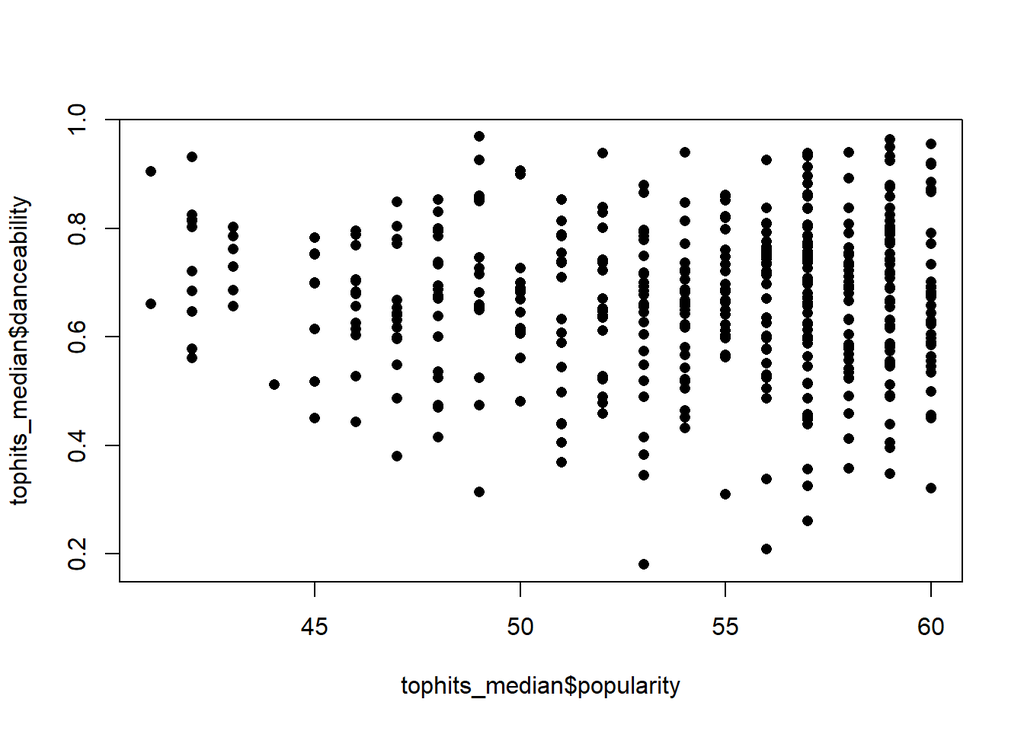

```r
plot(x = tophits_median$popularity,
     y = tophits_median$danceability,
     pch = 16)
```

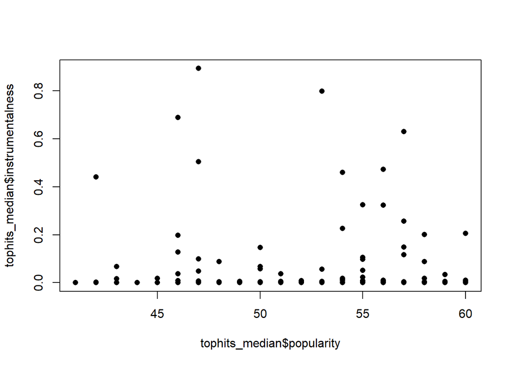

```r
plot(x = tophits_median$popularity,
     y = tophits_median$instrumentalness,
     pch = 16)
```

## 4.3 Min

```r
tophits_min <- subset(top_hits4, popularity_range %in% '0-10')
summary(tophits_min)
```

```
##            artist        song             duration_s     explicit
##  Adele        :  6   Length:169         Min.   :127.9   Mode :logical
##  T-Pain       :  5   Class :character   1st Qu.:196.6   FALSE:125
##  Ariana Grande:  4   Mode  :character   Median :214.6   TRUE :44
##  Mariah Carey :  4                      Mean   :217.0
##  Maroon 5     :  3                      3rd Qu.:236.1
##  Olly Murs    :  3                      Max.   :300.0
##  (Other)      :144
##       year      popularity      danceability        energy            key
##  2017   :25   Min.   :0.0000   Min.   :0.1290   Min.   :0.2030   0      :21
##  2016   :19   1st Qu.:0.0000   1st Qu.:0.6000   1st Qu.:0.6080   2      :20
##  2013   :15   Median :0.0000   Median :0.6760   Median :0.7350   1      :19
##  2014   :14   Mean   :0.5976   Mean   :0.6671   Mean   :0.7089   11     :19
##  2015   :14   3rd Qu.:1.0000   3rd Qu.:0.7440   3rd Qu.:0.8290   5      :18
##  2011   :13   Max.   :8.0000   Max.   :0.9060   Max.   :0.9850   7      :15
##  (Other):69                                                      (Other):57
##     loudness       mode     speechiness      acousticness
##  Min.   :-12.890   0: 66   Min.   :0.0249   Min.   :0.0000192
##  1st Qu.: -6.447   1:103   1st Qu.:0.0396   1st Qu.:0.0108000
##  Median : -5.350           Median :0.0560   Median :0.0543000
##  Mean   : -5.657           Mean   :0.0949   Mean   :0.1327433
##  3rd Qu.: -4.569           3rd Qu.:0.1080   3rd Qu.:0.1800000
##  Max.   : -2.063           Max.   :0.4380   Max.   :0.8930000
##
##  instrumentalness       liveness         valence           tempo
##  Min.   :0.0000000   Min.   :0.0315   Min.   :0.0381   Min.   : 66.0
##  1st Qu.:0.0000000   1st Qu.:0.0873   1st Qu.:0.3600   1st Qu.:102.4
##  Median :0.0000000   Median :0.1170   Median :0.5190   Median :120.0
##  Mean   :0.0268682   Mean   :0.1766   Mean   :0.5271   Mean   :120.2
##  3rd Qu.:0.0000734   3rd Qu.:0.2240   3rd Qu.:0.6820   3rd Qu.:129.0
##  Max.   :0.9250000   Max.   :0.8530   Max.   :0.9680   Max.   :198.1
##
##                    genre    popularity_range     key_name
##  pop                  :45   Length:169         Length:169
##  pop, Dance/Electronic:35   Class :character   Class :character
##  hip hop, pop, R&B    :17   Mode  :character   Mode  :character
##  pop, R&B             :12
##  hip hop              :11
##  hip hop, pop         :10
##  (Other)              :39
##  tempo_category      year_range
##  Length:169         Length:169
##  Class :character   Class :character
##  Mode  :character   Mode  :character
##
##
##
##
```

```r
genre_min <- tophits_min[c('genre', 'tempo_category')]
genre_min2 <- data.frame(table(genre_min))
```

```r
genre_cepat_min <- subset(genre_min2, tempo_category %in% 'Cepat')
genre_cepat_min2 <- genre_cepat_min[order(genre_cepat_min$Freq, decreasing = TRUE),]
head(genre_cepat_min2)
```

|  | genre | tempo_category | Freq |
| --- | --- | --- | --- |
| 24 | pop | Cepat | 30 |
| 26 | pop, Dance/Electronic | Cepat | 28 |
| 8 | hip hop | Cepat | 9 |
| 31 | pop, R&B | Cepat | 9 |
| 12 | hip hop, pop | Cepat | 8 |
| 16 | hip hop, pop, R&B | Cepat | 7 |

```r
genre_sedang_min <- subset(genre_min2, tempo_category %in% 'Sedang')
genre_sedang_min2 <- genre_sedang_min[order(genre_sedang_min$Freq, decreasing = TRUE),]
head(genre_sedang_min2)
```

|  | genre | tempo_category | Freq |
| --- | --- | --- | --- |
| 142 | pop | Sedang | 13 |
| 134 | hip hop, pop, R&B | Sedang | 8 |
| 144 | pop, Dance/Electronic | Sedang | 7 |
| 149 | pop, R&B | Sedang | 3 |
| 126 | hip hop | Sedang | 2 |
| 130 | hip hop, pop | Sedang | 2 |

```r
genre_lambat_min <- subset(genre_min2, tempo_category %in% 'Lambat')
genre_lambat_min2 <- genre_lambat_min[order(genre_lambat_min$Freq, decreasing = TRUE),]
head(genre_lambat_min2)
```

|  | genre | tempo_category | Freq |
| --- | --- | --- | --- |
| 75 | hip hop, pop, R&B | Lambat | 2 |
| 83 | pop | Lambat | 2 |
| 88 | pop, Folk/Acoustic | Lambat | 1 |
| 60 | country | Lambat | 0 |
| 61 | country, latin | Lambat | 0 |
| 62 | Dance/Electronic | Lambat | 0 |

```r
genre_min3 <- tophits_min[c('genre', 'year_range')]
genre_min4 <- data.frame(table(genre_min3))
```

```r
year_range_min <- subset(genre_min4, year_range %in% '2018-2020')
year_range_min2 <- year_range_min[order(year_range_min$Freq, decreasing = TRUE),]
head(year_range_min2)
```

|  | genre | year_range | Freq |
| --- | --- | --- | --- |
| 260 | pop | 2018-2020 | 4 |
| 244 | hip hop | 2018-2020 | 3 |
| 262 | pop, Dance/Electronic | 2018-2020 | 2 |
| 239 | Dance/Electronic | 2018-2020 | 1 |
| 252 | hip hop, pop, R&B | 2018-2020 | 1 |
| 266 | pop, latin | 2018-2020 | 1 |

```r
year_range_min3 <- subset(genre_min4, year_range %in% '2013-2017')
year_range_min4 <- year_range_min3[order(year_range_min3$Freq, decreasing = TRUE),]
head(year_range_min4)
```

|  | genre | year_range | Freq |
| --- | --- | --- | --- |
| 201 | pop | 2013-2017 | 25 |
| 203 | pop, Dance/Electronic | 2013-2017 | 23 |
| 185 | hip hop | 2013-2017 | 7 |
| 189 | hip hop, pop | 2013-2017 | 5 |
| 191 | hip hop, pop, Dance/Electronic | 2013-2017 | 5 |
| 193 | hip hop, pop, R&B | 2013-2017 | 4 |

```r
year_range_min5 <- subset(genre_min4, year_range %in% '2008-2012')
year_range_min6 <- year_range_min5[order(year_range_min5$Freq, decreasing = TRUE),]
head(year_range_min6)
```

|  | genre | year_range | Freq |
| --- | --- | --- | --- |
| 144 | pop, Dance/Electronic | 2008-2012 | 7 |
| 149 | pop, R&B | 2008-2012 | 7 |
| 134 | hip hop, pop, R&B | 2008-2012 | 6 |
| 142 | pop | 2008-2012 | 6 |
| 130 | hip hop, pop | 2008-2012 | 4 |
| 132 | hip hop, pop, Dance/Electronic | 2008-2012 | 2 |

```r
year_range_min7 <- subset(genre_min4, year_range %in% '2003-2007')
year_range_min8 <- year_range_min7[order(year_range_min7$Freq, decreasing = TRUE),]
head(year_range_min8)
```

|  | genre | year_range | Freq |
| --- | --- | --- | --- |
| 83 | pop | 2003-2007 | 10 |
| 75 | hip hop, pop, R&B | 2003-2007 | 4 |
| 85 | pop, Dance/Electronic | 2003-2007 | 2 |
| 90 | pop, R&B | 2003-2007 | 2 |
| 60 | country | 2003-2007 | 1 |
| 71 | hip hop, pop | 2003-2007 | 1 |

```r
year_range_min9 <- subset(genre_min4, year_range %in% '1998-2002')
year_range_min10 <- year_range_min9[order(year_range_min9$Freq, decreasing = TRUE),]
head(year_range_min10)
```

|  | genre | year_range | Freq |
| --- | --- | --- | --- |
| 15 | hip hop, pop, latin | 1998-2002 | 2 |
| 16 | hip hop, pop, R&B | 1998-2002 | 2 |
| 6 | Folk/Acoustic, rock | 1998-2002 | 1 |
| 26 | pop, Dance/Electronic | 1998-2002 | 1 |
| 1 | country | 1998-2002 | 0 |
| 2 | country, latin | 1998-2002 | 0 |

```r
duration_s_min <- aggregate(duration_s ~ year_range, tophits_min, mean)
head(duration_s_min)
```

|  | year_range | duration_s |
| --- | --- | --- |
| 1 | 1998-2002 | 258.0975 |
| 2 | 2003-2007 | 227.4089 |
| 3 | 2008-2012 | 218.0198 |
| 4 | 2013-2017 | 214.8765 |
| 5 | 2018-2020 | 188.1751 |

```r
danceability_min <- aggregate(danceability ~ year_range, tophits_min, mean)
head(danceability_min)
```

|  | year_range | danceability |
| --- | --- | --- |
| 1 | 1998-2002 | 0.6175000 |
| 2 | 2003-2007 | 0.6059583 |
| 3 | 2008-2012 | 0.6612250 |
| 4 | 2013-2017 | 0.6861379 |
| 5 | 2018-2020 | 0.6956667 |

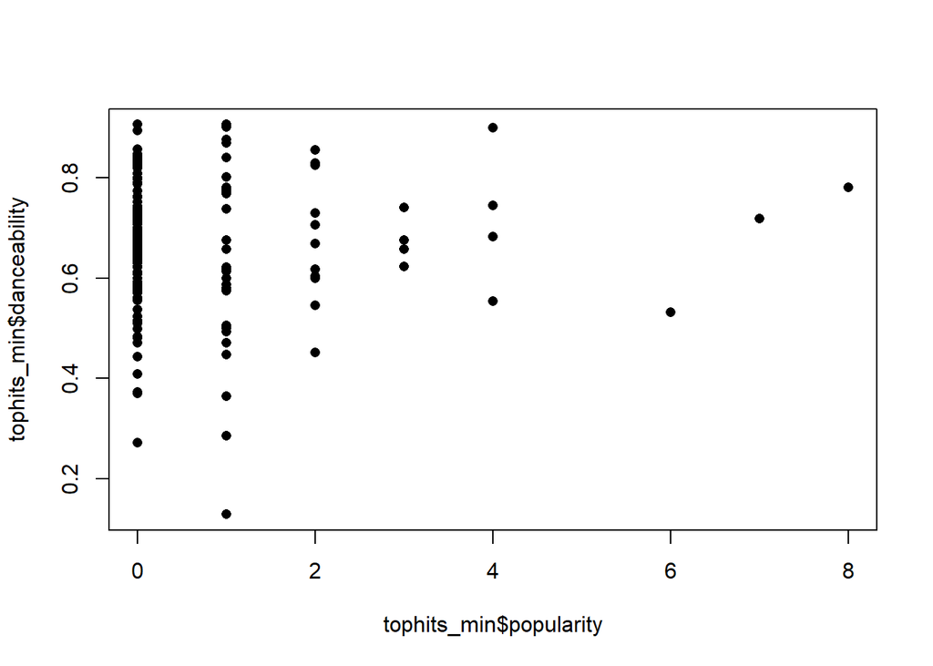

```r
plot(x = tophits_min$popularity,
     y = tophits_min$danceability,
     pch = 16)
```

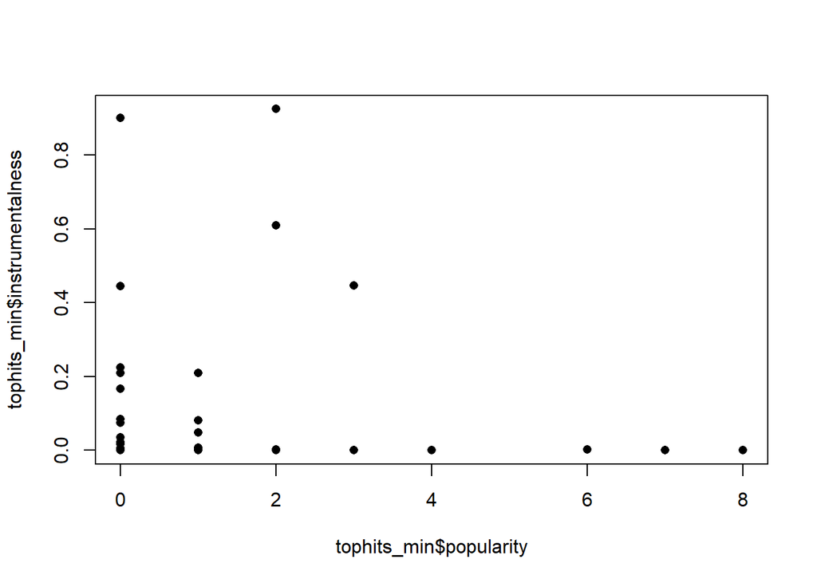

```r
plot(x = tophits_min$popularity,
     y = tophits_min$instrumentalness,
     pch = 16)
```